# DATA606 Homework8

Henry Otuadinma

May 05, 2019

#### 8.2 Baby weights, Part II:

1. Write the equation of the regression line.
2. Interpret the slope in this context, and calculate the predicted birth weight of first borns and others.
3. Is there a statistically significant relationship between the average birth weight and parity?

##### Answer:

1. y <- 120.07 - 1.93 * parity
2. firstBorns = 120.07; notFirstBorns = 120.07 - 1.93 = 118.14
3. There is no statistically significant relationship, since the t-value of -1.62 is diferent from the typical .05 alpha level.

1. Write the equation of the regression line.
2. Interpret each one of the slopes in this context.
3. Calculate the residual for the first observation in the data set: a student who is aboriginal, male, a slow learner, and missed 2 days of school.
4. The variance of the residuals is 240.57, and the variance of the number of absent days for all students in the data set is 264.17. Calculate the R2 and the adjusted R2. Note that there are 146 observations in the data set.

#### 8.8 Absenteeism, Part II:

The `no learner status` has the highest $R_{adj}^2 = 0.0723$, and it is higher than the $R_{adj}^2 = 0.0701$ of the full model. The `learner status` variable should be eliminated from the model first.

#### 8.16

##### Challenger disaster, Part I:

a). Out of 23 shuttle missions, it appears that missions launched at higher ambient tempreatures produced the least or no damaged O-rings. Also, the launch with the most damaged O-rings (5) happens to be the mission launched on the coldest ambient temperature (53 F). All missions launched in temperature below 65 F had at least one damaged O-ring. Out of 13 missions launched in temperature 70 F or higher, only 3 showed damaged O-rings. These two variables seem to be inversely related.

d). The p-value is practically 0 which shows that the failures are likely not due to chance. Moreover, there appears to be an inverse relationship between temperature and failures of the O-RINGS. So, I think it is justified to be concerned.

#### 8.18 Challenger disaster, Part II:

```r
p51<- exp(11.663-51*.2126)/(1+exp(11.663-51*.2126))
p51
```

```
## [1] 0.6943212
```

```r
p53<- exp(11.663-53*.2126)/(1+exp(11.663-53*.2126))
p53
```

```
## [1] 0.5975339
```

```r
p55<- exp(11.663-55*.2126)/(1+exp(11.663-55*.2126))
p55
```

```
## [1] 0.4925006
```

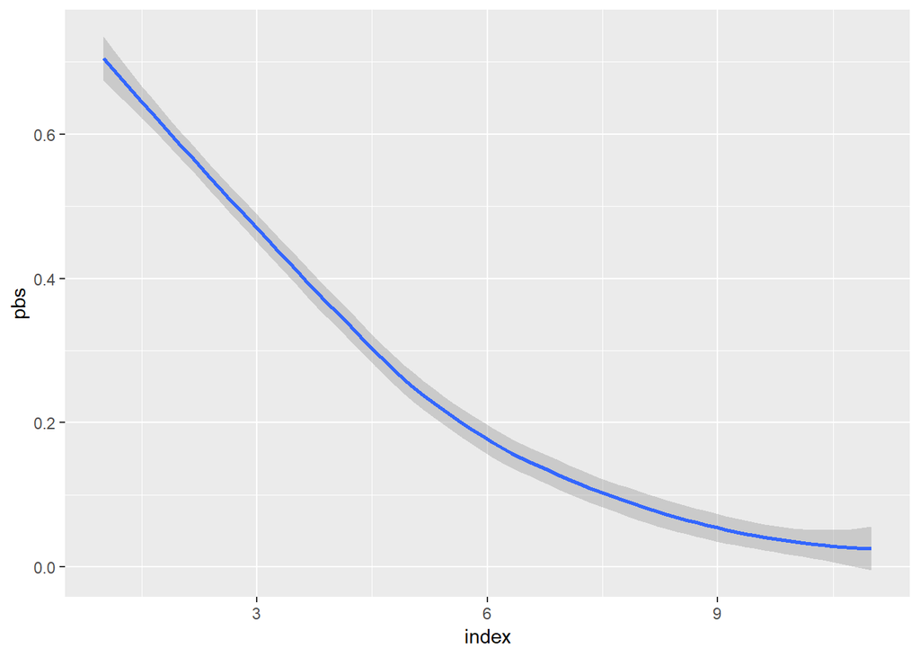

```r
probs <- data.frame(pbs = c(p51, p53, p55, .341, .251, .179, .124, .084, .056, .037, .024), index = c(1:11))

ggplot(probs) + geom_smooth(aes(y = pbs, x = index))
```

##### Binary codes (0 and 1) are used to denote either damaged or not for the O-rings without any indication about the degree of damage of the rings, and this could hold significant information. Moreover, there might be a situation whereby the rings were reused for different missions. The sample size of 23 diffrerent missions doesn’t seem large enough. The model could be improved by collecting more data on more missions